# ps04

## INFO 371 Problem Set 4 Distance Metric and k-NN

*Name*: Xiaobing Xu

*Section*: INFO 371 AA

*Date*: April 24th, 2022

```python
import matplotlib.pyplot as plt
from matplotlib.image import imread
from sklearn.cluster import KMeans
from sklearn.neighbors import KNeighborsClassifier
from sklearn.model_selection import cross_val_score
from sklearn.linear_model import LogisticRegression
import pandas as pd
import numpy as np
```

### 1.1 Explore data

#### 1. (1pt) Load the data. Ignore id.

```python
df = pd.read_csv("../Data/all-data/wdbc.csv.bz2").drop("id",axis=1)
df.head()
```

|  | diagnosis | radius.mean | texture.mean | perimeter.mean | area.mean | smoothness.mean | compactness.mean | concavity.mean | concpoints.mean | symmetry.mean | ... | radius.worst | texture.worst | perimeter.worst | area.worst | smoothness.worst | compactness.worst | concavity.worst | concpoints.worst | symmetry.worst | fracdim.worst |
| --- | --- | --- | --- | --- | --- | --- | --- | --- | --- | --- | --- | --- | --- | --- | --- | --- | --- | --- | --- | --- | --- |
| 0 | M | 17.99 | 10.38 | 122.80 | 1001.0 | 0.11840 | 0.27760 | 0.3001 | 0.14710 | 0.2419 | ... | 25.38 | 17.33 | 184.60 | 2019.0 | 0.1622 | 0.6656 | 0.7119 | 0.2654 | 0.4601 | 0.11890 |
| 1 | M | 20.57 | 17.77 | 132.90 | 1326.0 | 0.08474 | 0.07864 | 0.0869 | 0.07017 | 0.1812 | ... | 24.99 | 23.41 | 158.80 | 1956.0 | 0.1238 | 0.1866 | 0.2416 | 0.1860 | 0.2750 | 0.08902 |
| 2 | M | 19.69 | 21.25 | 130.00 | 1203.0 | 0.10960 | 0.15990 | 0.1974 | 0.12790 | 0.2069 | ... | 23.57 | 25.53 | 152.50 | 1709.0 | 0.1444 | 0.4245 | 0.4504 | 0.2430 | 0.3613 | 0.08758 |
| 3 | M | 11.42 | 20.38 | 77.58 | 386.1 | 0.14250 | 0.28390 | 0.2414 | 0.10520 | 0.2597 | ... | 14.91 | 26.50 | 98.87 | 567.7 | 0.2098 | 0.8663 | 0.6869 | 0.2575 | 0.6638 | 0.17300 |
| 4 | M | 20.29 | 14.34 | 135.10 | 1297.0 | 0.10030 | 0.13280 | 0.1980 | 0.10430 | 0.1809 | ... | 22.54 | 16.67 | 152.20 | 1575.0 | 0.1374 | 0.2050 | 0.4000 | 0.1625 | 0.2364 | 0.07678 |

5 rows × 31 columns

```python
df.describe()
```

|  | radius.mean | texture.mean | perimeter.mean | area.mean | smoothness.mean | compactness.mean | concavity.mean | concpoints.mean | symmetry.mean | fracdim.mean | ... | radius.worst | texture.worst | perimeter.worst | area.worst | smoothness.worst | compactness.worst | concavity.worst | concpoints.worst | symmetry.worst | fracdim.worst |
| --- | --- | --- | --- | --- | --- | --- | --- | --- | --- | --- | --- | --- | --- | --- | --- | --- | --- | --- | --- | --- | --- |
| count | 569.000000 | 569.000000 | 569.000000 | 569.000000 | 569.000000 | 569.000000 | 569.000000 | 569.000000 | 569.000000 | 569.000000 | ... | 569.000000 | 569.000000 | 569.000000 | 569.000000 | 569.000000 | 569.000000 | 569.000000 | 569.000000 | 569.000000 | 569.000000 |
| mean | 14.127292 | 19.289649 | 91.969033 | 654.889104 | 0.096360 | 0.104341 | 0.088799 | 0.048919 | 0.181162 | 0.062798 | ... | 16.269190 | 25.677223 | 107.261213 | 880.583128 | 0.132369 | 0.254265 | 0.272188 | 0.114606 | 0.290076 | 0.083946 |
| std | 3.524049 | 4.301036 | 24.298981 | 351.914129 | 0.014064 | 0.052813 | 0.079720 | 0.038803 | 0.027414 | 0.007060 | ... | 4.833242 | 6.146258 | 33.602542 | 569.356993 | 0.022832 | 0.157336 | 0.208624 | 0.065732 | 0.061867 | 0.018061 |
| min | 6.981000 | 9.710000 | 43.790000 | 143.500000 | 0.052630 | 0.019380 | 0.000000 | 0.000000 | 0.106000 | 0.049960 | ... | 7.930000 | 12.020000 | 50.410000 | 185.200000 | 0.071170 | 0.027290 | 0.000000 | 0.000000 | 0.156500 | 0.055040 |
| 25% | 11.700000 | 16.170000 | 75.170000 | 420.300000 | 0.086370 | 0.064920 | 0.029560 | 0.020310 | 0.161900 | 0.057700 | ... | 13.010000 | 21.080000 | 84.110000 | 515.300000 | 0.116600 | 0.147200 | 0.114500 | 0.064930 | 0.250400 | 0.071460 |
| 50% | 13.370000 | 18.840000 | 86.240000 | 551.100000 | 0.095870 | 0.092630 | 0.061540 | 0.033500 | 0.179200 | 0.061540 | ... | 14.970000 | 25.410000 | 97.660000 | 686.500000 | 0.131300 | 0.211900 | 0.226700 | 0.099930 | 0.282200 | 0.080040 |
| 75% | 15.780000 | 21.800000 | 104.100000 | 782.700000 | 0.105300 | 0.130400 | 0.130700 | 0.074000 | 0.195700 | 0.066120 | ... | 18.790000 | 29.720000 | 125.400000 | 1084.000000 | 0.146000 | 0.339100 | 0.382900 | 0.161400 | 0.317900 | 0.092080 |
| max | 28.110000 | 39.280000 | 188.500000 | 2501.000000 | 0.163400 | 0.345400 | 0.426800 | 0.201200 | 0.304000 | 0.097440 | ... | 36.040000 | 49.540000 | 251.200000 | 4254.000000 | 0.222600 | 1.058000 | 1.252000 | 0.291000 | 0.663800 | 0.207500 |

8 rows × 30 columns

#### 3. (3pt) What would be the accuracy of the naive model, such model that predicts every case to the majority category?

```python
df.diagnosis.value_counts()
```

```
B    357
M    212
Name: diagnosis, dtype: int64
```

```python
357/(357+212) #the accuracy
```

```
0.6274165202108963
```

#### 1.2 Feature transformation

#### 1.2.1

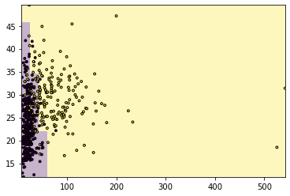

```python
from sklearn.linear_model import LogisticRegression
import matplotlib.pyplot as plt
x1 = df["area.se"]
x2 = df["texture.worst"]
y = df.diagnosis == "M"
X = np.column_stack((x1, x2))
m = LogisticRegression(solver="lbfgs").fit(X, y)
# Now greate the regular grid
ex1 = np.linspace(x1.min(), x1.max(), 30) # 30 elements
ex2 = np.linspace(x2.min(), x2.max(), 30)
xx1, xx2 = np.meshgrid(ex1, ex2)
# meshgrid creates two 30x30 matrices
g = np.column_stack((xx1.ravel(), xx2.ravel()))
# we create the design matrix by stacking the xx1, xx2
# after unraveling those into columns
# predict on the grid
hatY = m.predict(g).reshape(30, 30)
# imshow wants a matrix, so we reshape the predicted 2 vector into one
_ = plt.imshow(hatY, extent=(x1.min(), x1.max(), x2.min(), x2.max()),
               aspect="auto", # let the image fit to screen
               interpolation='none', origin='lower',
# you need to specify that the image begins from below,
           # not above, otherwise it will be flipped around
                alpha=0.3)
_ = plt.scatter(x1, x2, c=y, edgecolor='k', s=8)
_ = plt.show()
```

```python
from sklearn.linear_model import LogisticRegression
import matplotlib.pyplot as plt
```

```python
#(a)
x1 = df["texture.mean"]
x2 = df["concpoints.mean"]
y = df.diagnosis == "M"
X = np.column_stack((x1, x2))
#m = LogisticRegression(solver="lbfgs").fit(X, y)
m = KNeighborsClassifier(7).fit(X, y)
cv = cross_val_score(m, X, y, cv=10)
np.mean(cv)
```

```
0.7114974937343359
```

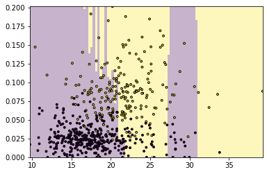

```python
#(b)
ex1 = np.linspace(x1.min(), x1.max(), 100) # 30 elements
ex2 = np.linspace(x2.min(), x2.max(), 100)
xx1, xx2 = np.meshgrid(ex1, ex2)
g = np.column_stack((xx1.ravel(), xx2.ravel()))
hatY = m.predict(g).reshape(100, 100)
_ = plt.imshow(hatY, extent=(x1.min(), x1.max(), x2.min(), x2.max()),
               aspect="auto",
               interpolation='none', origin='lower',
                alpha=0.3)
_ = plt.scatter(x1, x2, c=y, edgecolor='k', s=8)
_ = plt.show()
```

The stripes are caused by the difference in scales for x and y axis, and the scale for x axis is way larger than y axis, so the y axis has been stretched.

```python
#(c)
cross_val_score(m, X, y, scoring="accuracy")
```

```
array([0.70175439, 0.71929825, 0.76315789, 0.70175439, 0.65486726])
```

```python
from sklearn.decomposition import PCA
Xn = np.empty_like(X)
x1n = (x1 - x1.mean())/x1.std()
x2n = (x2 - x2.mean())/x2.std()
Xn = np.column_stack((x1n,x2n))
m = KNeighborsClassifier(7).fit(Xn, y)
cv = cross_val_score(m, Xn, y, cv=10)
np.mean(cv)
```

```
0.9208646616541353
```

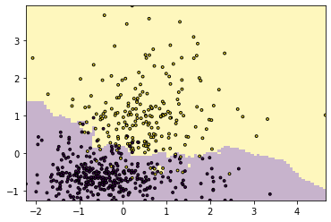

```python
ex1 = np.linspace(x1n.min(), x1n.max(), 100) # 30 elements
ex2 = np.linspace(x2n.min(), x2n.max(), 100)
xx1, xx2 = np.meshgrid(ex1, ex2)
g = np.column_stack((xx1.ravel(), xx2.ravel()))
hatY = m.predict(g).reshape(100, 100)
_ = plt.imshow(hatY, extent=(x1n.min(), x1n.max(), x2n.min(), x2n.max()),
               aspect="auto", # let the image fit to screen
               interpolation='none', origin='lower',
# you need to specify that the image begins from below,
           # not above, otherwise it will be flipped around
                alpha=0.3)
_ = plt.scatter(x1n, x2n, c=y, edgecolor='k', s=8)
_ = plt.show()
```

#### 1.2.3

After normalizing the data, the two features are brought to the same scale, which results in the he normalied one looks different and better than original. This would helps us understand their effects earlier. Then accuracy here is better than the original one because of reason as well. The accuracy of original features is 0.712 which is smaller than the normalized features which is 0.921.

#### 1.2.4 ow use the original (non-normalized) features and repeat the process. However, this time use Mahalanobis distance

```python
x1 = df["texture.mean"]
x2 = df["concpoints.mean"]
y = df.diagnosis == "M"
X = np.column_stack((x1, x2))
#m = LogisticRegression(solver="lbfgs").fit(X, y)
Sigma = np.cov(X, rowvar=False)
mahalanobis_m = KNeighborsClassifier(n_neighbors=1,
                         metric="mahalanobis",
                         metric_params={"V":Sigma}).fit(X, y)
cv = cross_val_score(mahalanobis_m, X, y, cv=10)
np.mean(cv)
```

```
0.8751566416040099
```

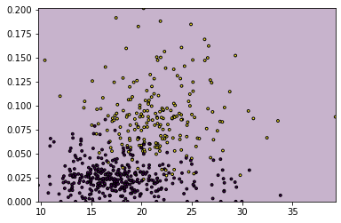

```python
ex1 = np.linspace(x1.min(), x1.max(), 100) # 30 elements
ex2 = np.linspace(x2.min(), x2.max(), 100)
xx1, xx2 = np.meshgrid(ex1, ex2)
g = np.column_stack((xx1.ravel(), xx2.ravel()))
hatY = m.predict(g).reshape(100, 100)
_ = plt.imshow(hatY, extent=(x1.min(), x1.max(), x2.min(), x2.max()),
               aspect="auto", # let the image fit to screen
               interpolation='none', origin='lower',
# you need to specify that the image begins from below,
           # not above, otherwise it will be flipped around
                alpha=0.3)
_ = plt.scatter(x1, x2, c=y, edgecolor='k', s=8)
_ = plt.show()
```

#### 1.2.5 Repeat all these steps with a few other sets of two features and a few other k-s of your choice.

#### original

```python
x1 = df["concavity.mean"]
x2 = df["compactness.mean"]
y = df.diagnosis == "M"
X = np.column_stack((x1, x2))
#m = LogisticRegression(solver="lbfgs").fit(X, y)
m = KNeighborsClassifier(3).fit(X, y)
cv = cross_val_score(m, X, y, cv=10)
np.mean(cv)
```

```
0.862907268170426
```

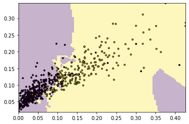

```python
ex1 = np.linspace(x1.min(), x1.max(), 100) # 30 elements
ex2 = np.linspace(x2.min(), x2.max(), 100)
xx1, xx2 = np.meshgrid(ex1, ex2)
g = np.column_stack((xx1.ravel(), xx2.ravel()))
hatY = m.predict(g).reshape(100, 100)
_ = plt.imshow(hatY, extent=(x1.min(), x1.max(), x2.min(), x2.max()),
               aspect="auto", # let the image fit to screen
               interpolation='none', origin='lower',
# you need to specify that the image begins from below,
           # not above, otherwise it will be flipped around
                alpha=0.3)
_ = plt.scatter(x1, x2, c=y, edgecolor='k', s=8)
_ = plt.show()
```

#### normalized

```python
x1n = (x1 - x1.mean())/x1.std()
x2n = (x2 - x2.mean())/x2.std()
Xn = np.column_stack((x1n,x2n))
X = np.column_stack((x1, x2))
#m = LogisticRegression(solver="lbfgs").fit(X, y)
m = KNeighborsClassifier(3).fit(X, y)
cv = cross_val_score(m, Xn, y, cv=10)
np.mean(cv)
```

```
0.8664473684210525
```

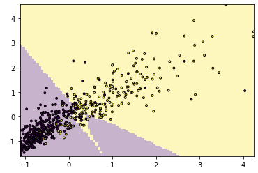

```python
ex1 = np.linspace(x1n.min(), x1n.max(), 100) # 30 elements
ex2 = np.linspace(x2n.min(), x2n.max(), 100)
xx1, xx2 = np.meshgrid(ex1, ex2)
g = np.column_stack((xx1.ravel(), xx2.ravel()))
hatY = m.predict(g).reshape(100, 100)
_ = plt.imshow(hatY, extent=(x1n.min(), x1n.max(), x2n.min(), x2n.max()),
               aspect="auto", # let the image fit to screen
               interpolation='none', origin='lower',
# you need to specify that the image begins from below,
           # not above, otherwise it will be flipped around
                alpha=0.3)
_ = plt.scatter(x1n, x2n, c=y, edgecolor='k', s=8)
_ = plt.show()
```

#### Mahalanobis-transformed

```python
x1 = df["concavity.mean"]
x2 = df["compactness.mean"]
y = df.diagnosis == "M"
X = np.column_stack((x1, x2))
#m = LogisticRegression(solver="lbfgs").fit(X, y)
Sigma = np.cov(X, rowvar=False)
mahalanobis_m = KNeighborsClassifier(n_neighbors=1,
                         metric="mahalanobis",
                         metric_params={"V":Sigma}).fit(X, y)
cv = cross_val_score(mahalanobis_m, X, y, cv=10)
np.mean(cv)
```

```
0.8294799498746868
```

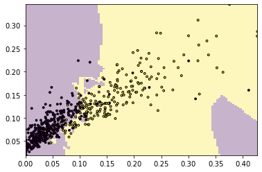

```python
ex1 = np.linspace(x1.min(), x1.max(), 100) # 30 elements
ex2 = np.linspace(x2.min(), x2.max(), 100)
xx1, xx2 = np.meshgrid(ex1, ex2)
g = np.column_stack((xx1.ravel(), xx2.ravel()))
hatY = m.predict(g).reshape(100, 100)
_ = plt.imshow(hatY, extent=(x1.min(), x1.max(), x2.min(), x2.max()),
               aspect="auto", # let the image fit to screen
               interpolation='none', origin='lower',
# you need to specify that the image begins from below,
           # not above, otherwise it will be flipped around
                alpha=0.3)
_ = plt.scatter(x1, x2, c=y, edgecolor='k', s=8)
_ = plt.show()
```

#### 1.2.6 Describe your observations.

How well do original/normalized/Mahalanobis-transformed features work? Does it depend on the features? Does the visual impression from images align with the cross-validation results?

### 2 Images: Reduce number of colors

```python
import matplotlib.pyplot as plt
from matplotlib.image import imread
```

[figure not shown]

```python
pixels = imread("Dubs.jpeg")
ax = plt.subplot(1,1,1)
ax.set_aspect("equal")
_ = plt.imshow(pixels)
_ = plt.show()
```

```python
pixels.shape
```

```
(1365, 1365, 3)
```

```python
M = pixels.reshape((-1,pixels.shape[2]))
print(M.shape)
```

```
(1863225, 3)
```

```python
from sklearn.cluster import KMeans
m = KMeans(16).fit(M)
cl = m.predict(M)
centers = m.cluster_centers_
print("center color values:\n", centers)
```

```
center color values:
 [[  8.12276235   6.19275184   6.25785318]
 [219.74936003 219.03631584 228.16629738]
 [128.36129476 117.72097967 112.09951392]
 [181.66215624 174.22077095 165.94612542]
 [ 73.79668923  65.60922268  64.06255089]
 [ 92.26661592  43.64039902 117.22746151]
 [230.32849731 230.12536997 238.7039479 ]
 [128.80748606  68.61574197 155.22397133]
 [ 50.10407097  42.67694373  44.14170809]
 [154.81469864 145.82984739 139.40015472]
 [206.24856089 204.23659119 213.47312044]
 [ 28.16506978  23.49624693  22.88565045]
 [202.37795166 194.60136688 180.95151545]
 [194.44346171 116.16648007 118.26298701]
 [189.9550151  176.09657028 132.60772765]
 [ 99.03424887  89.86713826  86.70948867]]
```

```python
compressed = centers[cl]/255
compressed = compressed.reshape(pixels.shape)
```

[figure not shown]

```python
ax = plt.subplot(1,1,1)
ax.set_aspect("equal")
_ = plt.imshow(compressed)
_ = plt.show()
```

The `pixels` records the RGB value for each data point in the images.

`M` reshapes the pixels from 3-d array into a 2-d array that stores the RGB information of each data point.

`cl` values indicate the cluster that each data point belongs to.

The the columns of “center color values” printed above indicates the RGB value for each centroid. The number means the RGB color number from 0 to 255.

```python
len(centers)*3
```

```
48
```

We have total of 48 center color values. We have those numbers to represent the color for each centroid.

```python
def num_colors(num):
    M = pixels.reshape((-1, pixels.shape[2]))
    m = KMeans(num).fit(M)
    cl = m.predict(M)
    centers = m.cluster_centers_
    compressed = (centers[cl] / 255).reshape(pixels.shape)
    ax = plt.subplot(1,1,1)
    ax.set_aspect("equal")
    _ = plt.imshow(compressed)
    _ = plt.show()
```

[figure not shown]

```python
num_colors(2)
```

[figure not shown]

```python
num_colors(4)
```